# RiseInTemp_dataset

IREM KOYUNLU

15 05 2020

# **ILERI REGRESYON ANALIZI**

# KURESEL ISINMA (IKLIM DEGISIKLIGI)

##### KAYNAK:https://www.kaggle.com/vageeshabudanur/riseintemp-dataset

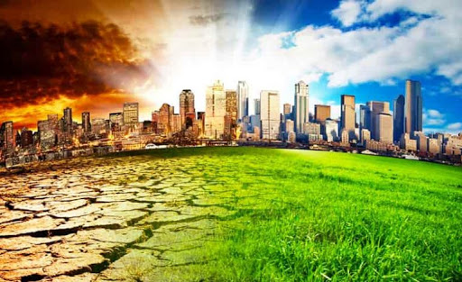

```r
library(readr)
      TempData=read.csv("C:/Users/CASPER/Desktop/climate_change.csv", header=T)


head(TempData,10)
```

```
##    Year Month    MEI    CO2     CH4     N2O  CFC.11  CFC.12      TSI Aerosols
## 1  1983     5  2.556 345.96 1638.59 303.677 191.324 350.113 1366.102   0.0863
## 2  1983     6  2.167 345.52 1633.71 303.746 192.057 351.848 1366.121   0.0794
## 3  1983     7  1.741 344.15 1633.22 303.795 192.818 353.725 1366.285   0.0731
## 4  1983     8  1.130 342.25 1631.35 303.839 193.602 355.633 1366.420   0.0673
## 5  1983     9  0.428 340.17 1648.40 303.901 194.392 357.465 1366.234   0.0619
## 6  1983    10  0.002 340.30 1663.79 303.970 195.171 359.174 1366.059   0.0569
## 7  1983    11 -0.176 341.53 1658.23 304.032 195.921 360.758 1366.107   0.0524
## 8  1983    12 -0.176 343.07 1654.31 304.082 196.609 362.174 1366.061   0.0486
## 9  1984     1 -0.339 344.05 1658.98 304.130 197.219 363.359 1365.426   0.0451
## 10 1984     2 -0.565 344.77 1656.48 304.194 197.759 364.296 1365.662   0.0416
##     Temp
## 1  0.109
## 2  0.118
## 3  0.137
## 4  0.176
## 5  0.149
## 6  0.093
## 7  0.232
## 8  0.078
## 9  0.089
## 10 0.013
```

### Veri Seti Aciklamasi ;

Gecen yuzyil boyunca ortalama kuresel sicakligin artmakta oldugunu belgeleyen bircok calisma yapilmistir. Kuresel sicaklikta devam eden artisin sonuclari korkunc olacaktir. Artan deniz seviyeleri ve artan asiri hava olaylari sikligi milyarlarca insani etkileyecektir. Bu veri, ortalama kuresel sicaklik ve diger bircok faktor arasindaki iliskiyi icermektedir. 308 gozlem 11 sutun bulunmakta.

Climate_change.csv dosyasi, Mayis 1983 ile Aralik 2008 arasindaki iklim verilerini icerir.

CO2, N20 ve CH4 ppmv cinsinden ifade edilir (hacimce milyonda parca sayisi;Yani, 397 ppmv CO2, CO2’nin atmosferin toplam hacminin 397 milyonuncu kismini olusturdugu anlamina gelir). CFC.11 ve CFC.12, ppbv cinsinden ifade edilir (hacim basina milyarda parca).

### Degiskenler:

Year (Yil ): Verinin gozlem yili.

Month (Ay): Verinin gozlem ayi.

MEI: Cok degiskenli El Nino Guney salinim indeksi (MEI). Gucunun bir olcusu; El Nino / La Nina-Guney salinim (kuresel sicakliklari etkileyen Pasifik Okyanusu’nda bir hava etkisi) Guney Amerika’nin Bati kiyisindaki Buyuk Okyanus’ta yuzey sularinin isinmasina Ispanyolca’da “erkek cocuk” anlamina gelen El Nino, sogumasina ise “kiz cocuk” anlamina gelen La Nina deniliyor. El Nino, ormanlarin ve bitki ortusunun karbondioksit emilimini azaltiyor. Bu nedenle daha fazla karbondioksit atmosferde kaliyor bu da kuresel sicakligi etkiliyor.

CO2: Atmosferik karbondioksit konsantrasyonlari (CO2). Hava sicak oldugunda karbondioksit miktarinin fazla, soguk oldugunda ise karbondioksit miktarinin az oldugunu bilinmekte.Kuresel sicaklik artisinin en buyuk etkenlerinden biridir.

CH4: Metan (CH4). Karbondioksitten 23 kat daha guclu olan metan gazi, kuresel sicaklik artisinin en onemli unsurlarindan biri.

N2O: Nitroz oksit (Azot Protoksit). Nitroz oksit gazi da dogal kaynaklar , suni gubre kullanimi ve endustri gibi insani kaynaklardan olusuyor, kuresel sicaklik artisini etkiliyor.

CFC.11: Trikloroflorometan (CCl3F; yaygin olarak CFC-11 olarak adlandirilir.) Ozon tabakasinin delinmesine yol acan kimyasal gaz (evlerin yalitiminda kullaniliyor ). kuresel sicaklik artisini etkiliyor.

CFC.12: Diklorodiflorometan (CCl2F2; yaygin olarak CFC-12 olarak adlandirilir.) Sera etkisi yaratan zararli gaz,kuresel sicaklik artisini etkiliyor.

TSI:W/m2 cinsinden toplam gunes isinimi (TSI). (gunes enerjisinin birim alan basina biriktirildigi oran). Gunes lekeleri ve diger gunes olaylari nedeniyle, gunes tarafindan verilen enerji miktari zamanla buyuk olcude degisir.

Aerosols: 550 nm’de ortalama stratosferik aerosol optik derinligi. Bu degisken volkanlarla baglantilidir, cunku volkanik patlamalar atmosfere yeni parcaciklarin eklenmesiyle sonuclanir, bu da gunes enerjisinin ne kadarinin uzaya yansidigini etkiler.

Temp:Bu veride ortalama kuresel sicaklik ve referans degeri arasindaki santigrat derece farki. Bu bagimli degiskendir.

##### Degiskenleri Aciklamada Kullanilan Ek Bilgi Kaynaklari:

https://www.bbc.com/turkce/haberler-46308251 http://www.imo.org.tr/resimler/ekutuphane/pdf/16154_50_07.pdf

Degisken turleri dogru mu diye kontrol icin ozetine bakalim;

```r
summary(TempData)
```

```
##       Year          Month             MEI               CO2
##  Min.   :1983   Min.   : 1.000   Min.   :-1.6350   Min.   :340.2
##  1st Qu.:1989   1st Qu.: 4.000   1st Qu.:-0.3987   1st Qu.:353.0
##  Median :1996   Median : 7.000   Median : 0.2375   Median :361.7
##  Mean   :1996   Mean   : 6.552   Mean   : 0.2756   Mean   :363.2
##  3rd Qu.:2002   3rd Qu.:10.000   3rd Qu.: 0.8305   3rd Qu.:373.5
##  Max.   :2008   Max.   :12.000   Max.   : 3.0010   Max.   :388.5
##       CH4            N2O            CFC.11          CFC.12           TSI
##  Min.   :1630   Min.   :303.7   Min.   :191.3   Min.   :350.1   Min.   :1365
##  1st Qu.:1722   1st Qu.:308.1   1st Qu.:246.3   1st Qu.:472.4   1st Qu.:1366
##  Median :1764   Median :311.5   Median :258.3   Median :528.4   Median :1366
##  Mean   :1750   Mean   :312.4   Mean   :252.0   Mean   :497.5   Mean   :1366
##  3rd Qu.:1787   3rd Qu.:317.0   3rd Qu.:267.0   3rd Qu.:540.5   3rd Qu.:1366
##  Max.   :1814   Max.   :322.2   Max.   :271.5   Max.   :543.8   Max.   :1367
##     Aerosols            Temp
##  Min.   :0.00160   Min.   :-0.2820
##  1st Qu.:0.00280   1st Qu.: 0.1217
##  Median :0.00575   Median : 0.2480
##  Mean   :0.01666   Mean   : 0.2568
##  3rd Qu.:0.01260   3rd Qu.: 0.4073
##  Max.   :0.14940   Max.   : 0.7390
```

Summary kodu ile bakildiginda month duzeltilmeli.Kategorik degisken icin mean hesaplanmaz.

```r
TempData$Month<-factor(TempData$Month)
summary(TempData)
```

```
##       Year          Month          MEI               CO2             CH4
##  Min.   :1983   5      : 26   Min.   :-1.6350   Min.   :340.2   Min.   :1630
##  1st Qu.:1989   6      : 26   1st Qu.:-0.3987   1st Qu.:353.0   1st Qu.:1722
##  Median :1996   7      : 26   Median : 0.2375   Median :361.7   Median :1764
##  Mean   :1996   8      : 26   Mean   : 0.2756   Mean   :363.2   Mean   :1750
##  3rd Qu.:2002   9      : 26   3rd Qu.: 0.8305   3rd Qu.:373.5   3rd Qu.:1787
##  Max.   :2008   10     : 26   Max.   : 3.0010   Max.   :388.5   Max.   :1814
##                 (Other):152
##       N2O            CFC.11          CFC.12           TSI
##  Min.   :303.7   Min.   :191.3   Min.   :350.1   Min.   :1365
##  1st Qu.:308.1   1st Qu.:246.3   1st Qu.:472.4   1st Qu.:1366
##  Median :311.5   Median :258.3   Median :528.4   Median :1366
##  Mean   :312.4   Mean   :252.0   Mean   :497.5   Mean   :1366
##  3rd Qu.:317.0   3rd Qu.:267.0   3rd Qu.:540.5   3rd Qu.:1366
##  Max.   :322.2   Max.   :271.5   Max.   :543.8   Max.   :1367
##
##     Aerosols            Temp
##  Min.   :0.00160   Min.   :-0.2820
##  1st Qu.:0.00280   1st Qu.: 0.1217
##  Median :0.00575   Median : 0.2480
##  Mean   :0.01666   Mean   : 0.2568
##  3rd Qu.:0.01260   3rd Qu.: 0.4073
##  Max.   :0.14940   Max.   : 0.7390
##
```

Modelimizi olusturalim .Bu verimizde bagimli degiskenimiz Temp tir(yanit degiskeni). Year ve month degiskenleri haric diger degiskenler aciklayici degiskenimiz olacaktir.

```r
lmod1 <- lm( Temp~
               MEI+
               CO2+
               CH4+
               N2O+
               CFC.11+
               CFC.12+
               Aerosols+
               TSI ,data=TempData) #Olusturdugum modeli lmdod1 diye adlandirdim.
```

Olusturdugum modeli lmod1 diye adlandirdim.

```r
head(fitted(lmod1),15) #Head komutu ile sadece 15 tanesini gosterdik.
```

```
##           1           2           3           4           5           6
##  0.16307026  0.14825658  0.14019475  0.11349428  0.04886278  0.01390213
##           7           8           9          10          11          12
##  0.02015506  0.02967373 -0.03122330 -0.01550142  0.08620368  0.05100123
##          13          14          15
##  0.06264959  0.07189982  0.06501410
```

Fitted komutu lm ile kurulan modelin fit edilmis y sapka degerlerini verir.

```r
head(residuals(lmod1),15) #Head komutu ile sadece 15 tanesini gosterdik.
```

```
##            1            2            3            4            5            6
## -0.054070260 -0.030256582 -0.003194751  0.062505724  0.100137219  0.079097870
##            7            8            9           10           11           12
##  0.211844939  0.048326265  0.120223295  0.028501421 -0.037203683 -0.070001228
##           13           14           15
##  0.002350413 -0.087899818 -0.089014096
```

Kurulan regresyon modelinin artiklarini verir.

# 1- HATA ILE ILGILI VARSAYIMLAR

## A- NORMALLIK VARSAYIMININ TESTLERI

Regresyon analizinde kullandigimiz tum hipotez testleri ve guven araliklari normallik varsayimina dayalidir.Bu nedenle normallik varsayiminin kontrolu onemlidir.Normallik varsayimi artiklar uzerinden Q-Q plot yardimi ile inceleyelim;

Onceklikle Q-Q Plot cizdirelim ;

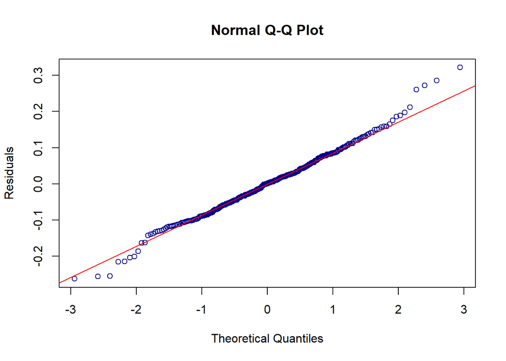

```r
qqnorm(residuals(lmod1),ylab="Residuals",col="darkblue")
qqline(residuals(lmod1),col="red")
```

Q-Q Plot grafigi artiklara karsilik cizilir. Grafigi cizdirdigimizde artiklar Q-Q Plot cizgisi uzerinde olur ise verimiz normal dagiliyor demektir. Grafikler yaniltici oldugundan testlere bakilir. Verimiz Q-Q Plot cizgisi uzerinde ciktigi icin normal dagildigini varsayariz.Grafikler yaniltici oldugundan diger testlere bakmaliyiz. Normallik sinamasi icin Shapiro-Wilk Testi (gozlem sayisi 50’nin altindaysa) ve Kolmogorov-Smirnov Testi (gozlem sayisi 50’nin ustundeyse) kullanilir. Simdi testlere bakalim ;Gozlem sayimiz 50 den fazla oldugu icin Kolmogorov-Smirnov Testine bakilmasi gerekir.

#### KOLMOGOROV SMIRNOV TEST

H0:Artiklar normal dagiliyor. H1:Artiklar normal dagilmiyor.

Normal dagilimin kontrolu icin gelistirilmis bir test. Gozlem sayisi 50 nin uzerinde ise kullanilir.

```r
ks.test(residuals(lmod1),"pnorm",
        mean=mean(residuals(lmod1)),
        sd=sd(residuals(lmod1)))
```

```
##
##  One-sample Kolmogorov-Smirnov test
##
## data:  residuals(lmod1)
## D = 0.033681, p-value = 0.8758
## alternative hypothesis: two-sided
```

Veri setimde gozlem sayim 50 nin uzerinde oldugundan Kolomogorov Smirnov Testi yapilir.Test sonucumda p-value=0.8758 cikti. 0.05 ’ den buyuk oldugu icin H0 hipotezi kabul edilir yani artiklarin dagilimi normaldir.

## B- SABIT VARYANS

Modelimin oncelikle plotuna bakiyorum; Sabit varyansi incelemek icin y sapkaya karsi artiklarin(e) grafigini cizdirmeliyiz;

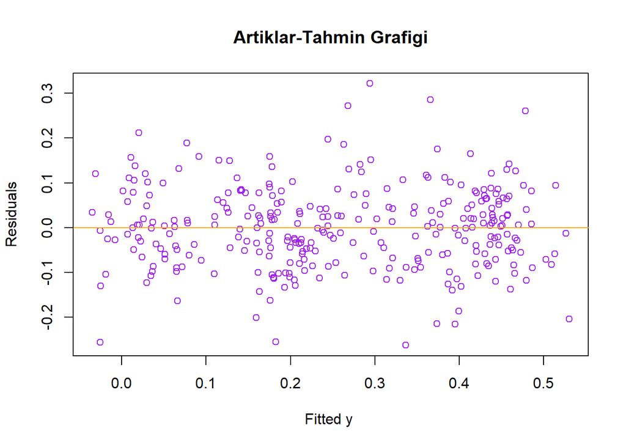

```r
plot( fitted(lmod1), residuals(lmod1),xlab="Fitted y ",ylab="Residuals",main="Artiklar-Tahmin Grafigi",col="purple")
abline(h=0,col="orange")
```

0 etrafinda nasil dagildigini gormek icin h=0 ile yataya cizgi ekledik. Duzgun bir grafik cikmadigi icin sabit varyansli mi emin olamiyoruz.Guvenilir olmasi icin degisken varyanslilik testlerine de bakmaliyiz.

### - DEGISKEN VARYANS TESTLERI

#### BREUSCH PAGAN TEST

H0:Heterosce Dosticity (Degisken Varyanslilik) problemi yok. H1:Heterosce Dosticity (Degisken Varyanslilik) problemi vardir.

```r
library(lmtest)
bptest(lmod1,data=TempData)
```

```
##
##  studentized Breusch-Pagan test
##
## data:  lmod1
## BP = 7.444, df = 8, p-value = 0.4896
```

Breusch Pagan Test sonucumda p-value=0.4896 cikti. 0.05 ’ den buyuk oldugu icin H0 hipotezi kabul edilir yani HETEROSCE DOSTICITY(degisken varyanslilik) problemi yoktur.

#### WHITE TEST

```r
wmod<-lm(residuals(lmod1)^2~fitted(lmod1)+fitted(lmod1)^2,TempData)
summary(wmod)
```

```
##
## Call:
## lm(formula = residuals(lmod1)^2 ~ fitted(lmod1) + fitted(lmod1)^2,
##     data = TempData)
##
## Residuals:
##       Min        1Q    Median        3Q       Max
## -0.008283 -0.007459 -0.004823  0.001987  0.095287
##
## Coefficients:
##                Estimate Std. Error t value Pr(>|t|)
## (Intercept)   0.0080401  0.0014953   5.377 1.51e-07 ***
## fitted(lmod1) 0.0005614  0.0049923   0.112    0.911
## ---
## Signif. codes:  0 '***' 0.001 '**' 0.01 '*' 0.05 '.' 0.1 ' ' 1
##
## Residual standard error: 0.01351 on 306 degrees of freedom
## Multiple R-squared:  4.133e-05,  Adjusted R-squared:  -0.003227
## F-statistic: 0.01265 on 1 and 306 DF,  p-value: 0.9105
```

White Test sonucumda p-value= 0.9105 cikti. 0.05 ’ den buyuk oldugu icin H0 hipotezi kabul edilir yani HETEROSCE DOSTICITY(degisken varyanslilik) problemi yoktur.Breusch Pagan Test sonucu ,White Testten daha guvenilirdir.

# 2- AYKIRI GOZLEMLERIN BELIRLENMESI (OLAGANDISI GOZLEMLER BULMA)

3 farkli tip aykiri gozlem vardir;

Outlier;Hatalari buyuk olan gozlemlere denir.(Model tarafindan iyi tahmin edilemez.) Influential;Parametreleri (betalari) degistirir. Leverage; x uzayinin merkezine uzak olan gozlemlere denir.

## A)LEVERAGE

Leverage tespiti icin hat matrisinin kosegen elemanlari kullanilir. Herhangi bir gozlemin elemani cut point degerinden buyukse o gozleme Leverage suphesiyle yaklasilir.

Once regresyon modeli kurulur hat valuesle degerler hesaplanir; n: Gozlem sayisi. p: Degisken sayisi+1, Cut point degerim; 2p/n . Cut point degerimden buyuk olan hat matrisinin kosegen elamani leverage adayi demektir.

```r
hatv <- hatvalues(lmod1) #sapka matrisinin kosegen elemanlari
head(hatv,15)
```

```
##          1          2          3          4          5          6          7
## 0.08867497 0.07791777 0.07136349 0.06936140 0.06045417 0.06358753 0.05525247
##          8          9         10         11         12         13         14
## 0.04947510 0.05329869 0.04864966 0.04431911 0.04177722 0.03935979 0.04815078
##         15
## 0.05079924
```

```r
sum(hatv)
```

```
## [1] 9
```

cut point degerim 2p/n(p: degisken sayisi+1 ,n:gozlem sayisi) den buyukse o gozlem leverage olabilir diye dusunuyoruz. Kurdugum regresyon modelinde 8 degiskenim oldugu icin p:8+1=9 (Beta0 ile birlikte) tane gozlemim var.

Cut point degerim : 2p/n oldugu icin. 2.p=2.9=18

```r
cut <- 18/length(TempData$Temp)
cut
```

```
## [1] 0.05844156
```

Cut point degerim 0.05844156 cikti.

```r
which(hatv>cut)
```

```
##   1   2   3   4   5   6 103 104 105 106 107 108 109 110 112 113 173
##   1   2   3   4   5   6 103 104 105 106 107 108 109 110 112 113 173
```

Cut Pointimden buyuk olan hat matrisinin kosegen elemanlari,Leverage adaylaridir. 1,2,3,4,5,6,103,104,105,106,107,108,109,110,112,113 ve 173. gozlemler leverage adaylaridir.

Half-Normal Plot ile gorsellestirme yapalim;

#### HALF-NORMAL PLOT

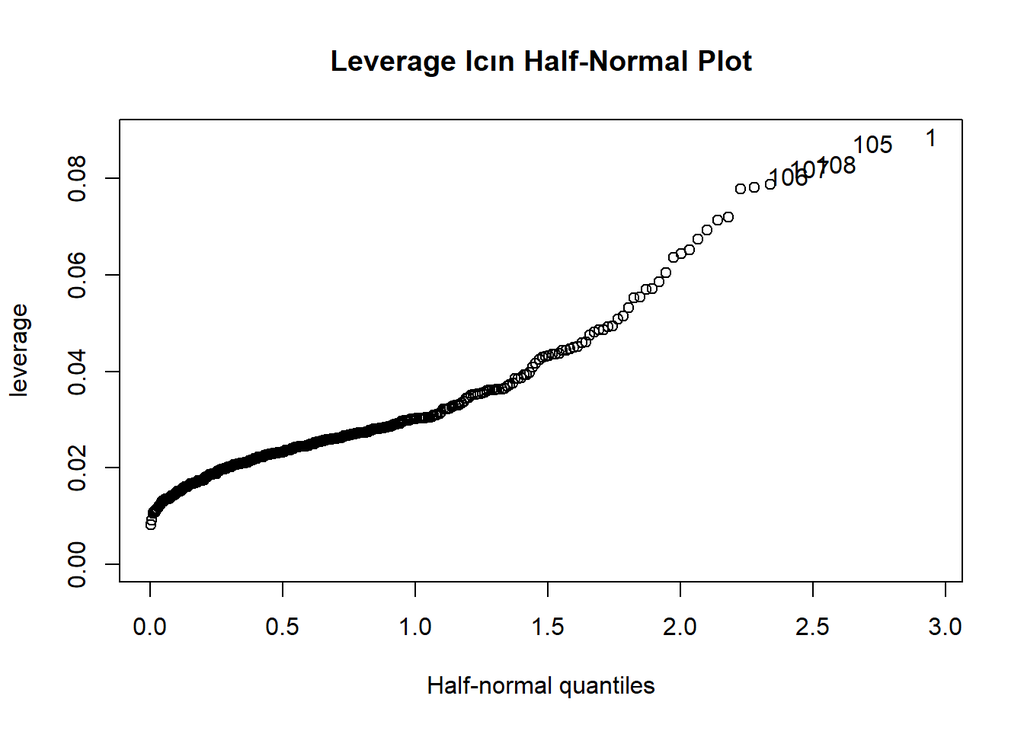

```r
library(faraway)
halfnorm(hatv,5,ylab="leverage",main="Leverage Icın Half-Normal Plot") # sira disi gozlemlerimin 5 ini gosterdim
```

Hat matrisi icin cizdirdigimiz half-normal plot grafiginde sadece en aykiri 5 gozlemimin gosterilmesini istedik. Cut point sonucumuz ile Half-Normal grafiginde gozuken sonuclar ayni cikmistir.

#### VARSAYIM BOZUNUMU KONTROLU

Verimizde varsayim bozunumu yok ise ham artiklar uzerinden cizdirilen Q-Q Plot ile standartlastirilmis artiklar uzerinden cizdirilmis olan Q-Q Plot gorsel olarak birbirlerine benzemeli.

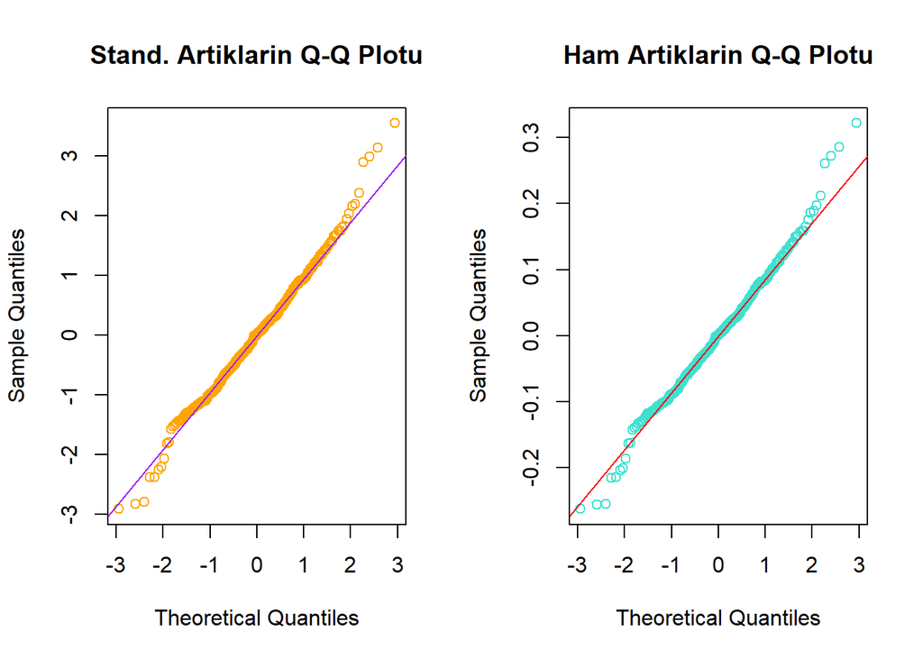

```r
par(mfrow=c(1,2)) #iki grafigide yan yana gosterir
qqnorm(rstandard(lmod1),main="Stand. Artiklarin Q-Q Plotu",col="orange") #standartlastirilmis artiklarin qq-plot u
qqline(rstandard(lmod1),col="purple")

qqnorm(residuals(lmod1),main="Ham Artiklarin Q-Q Plotu",col="turquoise") #ham artiklarin qq-plot u
qqline(residuals(lmod1),col="red")
```

Grafiklerde de gozuktugu uzere varsayim bozunumu yoktur.Iki grafikte de degiskenlerin cogu cizginin ustunde cikmistir ve birbirine benzemektedir.

## B)OUTLIER

#### STUDENTIZED ARTIKLAR BENFERRONI TESTI

```r
stud <- rstudent(lmod1)
stud[which.max(abs(stud))]
```

```
##      184
## 3.614831
```

Standartlastirilmis artiklarimin mutlakca en buyugune bakiyoruz. En buyuk standartlastirilmis artik (rstudent) degerim 184. gozlem olup degeri 3.614831 dir.

Cut point belirlemeliyiz,cut point degeri alfa/2n dir. Rstudentler (n-p-1) serbestlik dersceli t-dagilimina sahiptir.

```r
qt(0.05/(length(stud)*2) , (length(TempData$Temp)-9-1)) #(alfa/2n),(n-p-1)
```

```
## [1] -3.820115
```

Mutlakca cut point degerimden buyuk olan standartlastirilmis artik degeri bizim icin outlier olcaktir. Verimde en buyuk mutlak standartlastirilmis artik degerini 184. gozlem =3.614831 olarak bulmustuk. 184. gozlem =|3.614831| < |3.820115| oldugundan 184. gozlem bizim icin outlier degildir.

Outlier rstudent tipi artiklar icin halfnorm cizdirmeye gerek yok.

## C)INFLUENTIAL

Influential Parametreleri (betalari) degistirir.Bir etkili gozlem ayni zamanda bir outlier veya leverage olabilir. Etkinligi olcmek icin cook-distance yontemini kullanmaliyiz.

#### COOK-DISTANCE

```r
cook <- cooks.distance(lmod1)
head(cook,15)
```

```
##            1            2            3            4            5            6
## 4.114053e-03 1.105695e-03 1.113158e-05 4.123764e-03 9.050653e-03 5.979512e-03
##            7            8            9           10           11           12
## 3.661465e-02 1.685484e-03 1.132834e-02 5.754802e-04 8.851882e-04 2.938438e-03
##           13           14           15
## 3.105404e-06 5.411798e-03 5.887856e-03
```

```r
max(cook)
```

```
## [1] 0.04936055
```

En buyuk cook distance degerim 0.04936055 dir ve bu deger 105. gozlemde vardir.

#### HALF-NORMAL PLOT

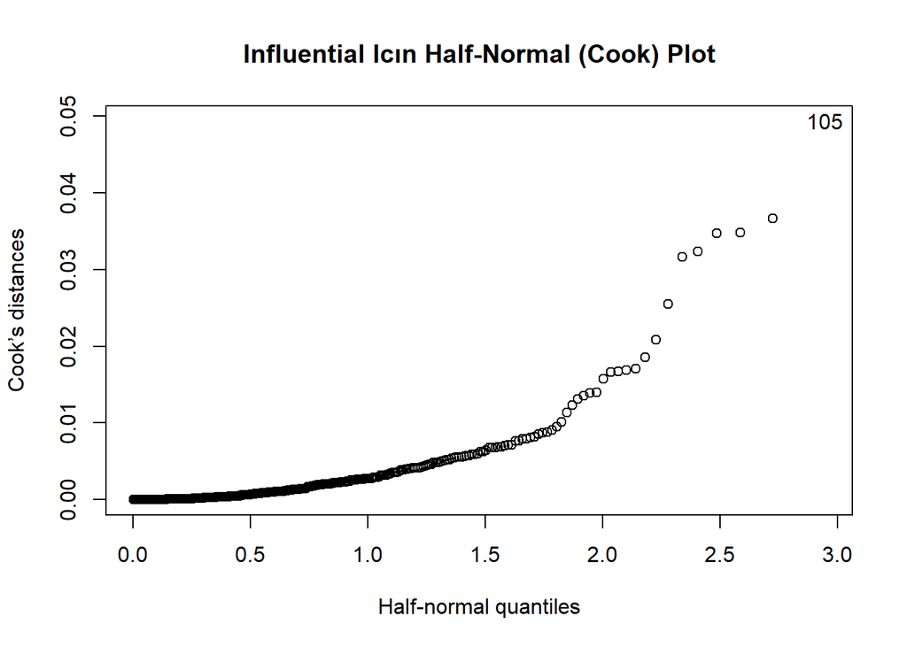

```r
halfnorm(cook,1,ylab="Cook’s distances",main="Influential Icın Half-Normal (Cook) Plot")
```

```r
cook[105]
```

```
##        105
## 0.04936055
```

Cook distance icin cizdirdigimiz half-normal plot grafiginde en etkili gozlemimin gosterilmesini istedik.En buyuk cook distance degerim 105.gozleme aittir. Cook Distance sonucum ile half-normal plot grafigindeki sonucum ayni ciktigindan 105. gozlemim etkili gozlemdir.

Bu gozlemi veriden cikardigimizda modelde ki degisimin nasil olacagini inceleyelim;

```r
lmod2 <- lm(Temp~
               MEI+
               CO2+
               CH4+
               N2O+
               CFC.11+
               CFC.12+
               Aerosols+
               TSI ,data=TempData, subset = cook < max(cook))
```

Iki model arasi degisime bakarsak;

```r
summary(lmod1)
```

```
##
## Call:
## lm(formula = Temp ~ MEI + CO2 + CH4 + N2O + CFC.11 + CFC.12 +
##     Aerosols + TSI, data = TempData)
##
## Residuals:
##      Min       1Q   Median       3Q      Max
## -0.26228 -0.05868  0.00051  0.05718  0.32170
##
## Coefficients:
##               Estimate Std. Error t value Pr(>|t|)
## (Intercept) -1.277e+02  1.919e+01  -6.654 1.36e-10 ***
## MEI          6.632e-02  6.186e-03  10.722  < 2e-16 ***
## CO2          5.207e-03  2.192e-03   2.375   0.0182 *
## CH4          6.371e-05  4.977e-04   0.128   0.8982
## N2O         -1.693e-02  7.835e-03  -2.161   0.0315 *
## CFC.11      -7.278e-03  1.461e-03  -4.980 1.07e-06 ***
## CFC.12       4.272e-03  8.763e-04   4.875 1.77e-06 ***
## Aerosols    -1.582e+00  2.099e-01  -7.535 5.86e-13 ***
## TSI          9.586e-02  1.401e-02   6.844 4.38e-11 ***
## ---
## Signif. codes:  0 '***' 0.001 '**' 0.01 '*' 0.05 '.' 0.1 ' ' 1
##
## Residual standard error: 0.09182 on 299 degrees of freedom
## Multiple R-squared:  0.744,  Adjusted R-squared:  0.7371
## F-statistic: 108.6 on 8 and 299 DF,  p-value: < 2.2e-16
```

```r
summary(lmod2)
```

```
##
## Call:
## lm(formula = Temp ~ MEI + CO2 + CH4 + N2O + CFC.11 + CFC.12 +
##     Aerosols + TSI, data = TempData, subset = cook < max(cook))
##
## Residuals:
##      Min       1Q   Median       3Q      Max
## -0.26006 -0.05951  0.00090  0.05723  0.31874
##
## Coefficients:
##               Estimate Std. Error t value Pr(>|t|)
## (Intercept) -1.259e+02  1.909e+01  -6.593 1.96e-10 ***
## MEI          6.606e-02  6.149e-03  10.744  < 2e-16 ***
## CO2          5.267e-03  2.179e-03   2.417   0.0162 *
## CH4         -1.310e-06  4.956e-04  -0.003   0.9979
## N2O         -1.797e-02  7.802e-03  -2.304   0.0219 *
## CFC.11      -7.517e-03  1.457e-03  -5.161 4.49e-07 ***
## CFC.12       4.447e-03  8.746e-04   5.085 6.52e-07 ***
## Aerosols    -1.690e+00  2.145e-01  -7.878 6.29e-14 ***
## TSI          9.482e-02  1.393e-02   6.807 5.50e-11 ***
## ---
## Signif. codes:  0 '***' 0.001 '**' 0.01 '*' 0.05 '.' 0.1 ' ' 1
##
## Residual standard error: 0.09125 on 298 degrees of freedom
## Multiple R-squared:  0.748,  Adjusted R-squared:  0.7412
## F-statistic: 110.5 on 8 and 298 DF,  p-value: < 2.2e-16
```

Iki model icin summary kodunu kullandigimizda, modeller arasinda degisimler vardir.Adjusted R-squared degerimiz az da olsa artmistir. CH4 degiskeninin katsayisinda gozle gorulur bir degisim olmustur.Tahminlerin tek bir gozleme bu kadar hassas olmasi istenmeyen bir durumdur.

Bu amacla dfbeta degerine bakmaliyiz.

Dfbeta her bir degisken icin ayri ayri dfbeta degeri veriyor.

```r
dfbeta <- dfbeta(lmod1)
head(dfbeta,5)
```

```
##   (Intercept)           MEI           CO2           CH4           N2O
## 1  0.70766159 -4.413596e-04 -1.229765e-04 -5.039192e-06  6.670995e-04
## 2  0.37573414 -1.916761e-04 -5.346524e-05  3.905179e-06  3.171070e-04
## 3  0.05268937 -1.544568e-05 -2.751617e-06  7.040433e-07  2.673505e-05
## 4 -1.18165430  1.485248e-04 -2.271089e-05 -2.320427e-05 -3.438887e-04
## 5 -1.06768933 -2.957679e-05 -1.525495e-04  5.951604e-06 -4.849339e-04
##          CFC.11        CFC.12      Aerosols           TSI
## 1  1.377566e-04 -5.740004e-05 -0.0146299794 -6.358033e-04
## 2  7.437055e-05 -3.495304e-05 -0.0073017061 -3.392874e-04
## 3  7.955493e-06 -3.935016e-06 -0.0006713937 -4.488509e-05
## 4 -1.590302e-04  8.511891e-05  0.0118507352  9.777218e-04
## 5 -2.684273e-04  1.244021e-04  0.0195977105  9.296338e-04
```

dfbeta icin cut point degeri hesaplamaliyiz. cut point:2/sqrt(n)

```r
cut <- 2/sqrt(length(TempData$Temp))
cut
```

```
## [1] 0.1139606
```

Cut point degerim 0.1139606 cikti. Cut pointten buyuk olan dfbeta degerleri bizim icin etkili gozlemdir.

dfbeta icin half normal plota cizdirirsek;

#### HALF-NORMAL PLOT

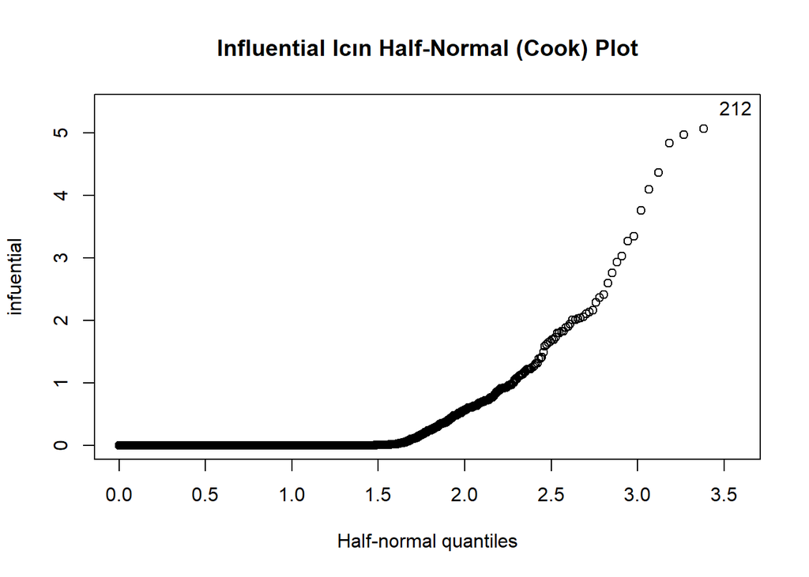

```r
halfnorm(dfbeta,1,ylab="infuential",main="Influential Icın Half-Normal (Cook) Plot")
```

Dfbeta icin half normal plot cizdirdigimizde 212. gozlemimiz etkili gozlemdir. Diger gozlemlerde etkilidir ama sadece en etkili olani gosterdik.

Dfbeta da her bir degiskenin etkisine ayri ayri plot cizdirerek bakmaliyiz;

[figure not shown]

```r
plot(dfbeta(lmod1)[,5],ylab = "change in CH4",main="CH4 Icın Plot",col="blue") # CH4 in model uzerine etkisine bakiyoruz.
abline(h=0,col="orange")
```

Dffit : Betalar arasindaki fark yerine tahminler arasindaki farka dayali bir olcuttur.

Dffit icin cut point= 2*sqrt(p/n) Cut point degerinden buyuk olanlar etkili gozlemdir denir.

```r
dffit <- dffits(lmod1)
head(dffit,15)
```

```
##            1            2            3            4            5            6
## -0.192222963 -0.099608653 -0.009992479  0.192487549  0.285532194  0.231901186
##            7            8            9           10           11           12
##  0.578565284  0.123017783  0.319739400  0.071859227 -0.089132562 -0.162514829
##           13           14           15
##  0.005277805 -0.220681000 -0.230193284
```

Dffit icin cut point degerim;

```r
cut <- 2*sqrt(9/length(TempData$Temp))
cut
```

```
## [1] 0.3418817
```

Cut point degerim 0.3418817 cikti. Cut point degerimden buyuk olan gozlemlere bakalim;

```r
which(abs(dffit)>cut)
```

```
##   7  20  63  83 105 106 115 127 178 183 184 190 210 211 212 236 297 299
##   7  20  63  83 105 106 115 127 178 183 184 190 210 211 212 236 297 299
```

Dffit icin cut pointi asan etkili gozlemleri gosterdik.7,20,63,83,105,106,115,127,178,183,184,190,210,211,212,236,297 ve 299. gozlemlerim etkili gozlemdir.

Half normal plot cizdirelim;

#### HALF-NORMAL PLOT

Dffit icin half normal plota bakarsak;

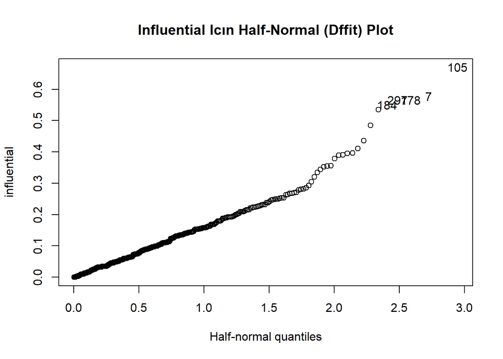

```r
halfnorm(dffit,5,ylab="influential",main="Influential Icın Half-Normal (Dffit) Plot")
```

Dffit icin half normal plot uzerinden en etkili 5 gozleme baktim.Diger gozlemlerde etkilidir ama sadece en etkili 5 tanesini gosterdik.

# 3)ACIKLAYICI DEGISKENLERLE ILGILI PROBLEMLER

## A)IC ILISKI (COLLINEARITY)

Iki degisken arasi lineer iliskiyi gosterir.Eger bir aciklayici degisken ve bir diger aciklayici degiskenin veya degiskenlerin lineer bir kombinasyonlari ise bu durumda x transpoz x matrisi (X’X) singuler olur ve tersi alinamaz. Bu durumdan ilgili degiskenlerden biri modelden cikartilarak kurtulunur. Gozlem sayisi arttikca ic iliski durumu azalir.

```r
lmod1 <- lm( Temp~
               MEI+
               CO2+
               CH4+
               N2O+
               CFC.11+
               CFC.12+
               Aerosols+
               TSI ,data=TempData)
summary(lmod1)
```

```
##
## Call:
## lm(formula = Temp ~ MEI + CO2 + CH4 + N2O + CFC.11 + CFC.12 +
##     Aerosols + TSI, data = TempData)
##
## Residuals:
##      Min       1Q   Median       3Q      Max
## -0.26228 -0.05868  0.00051  0.05718  0.32170
##
## Coefficients:
##               Estimate Std. Error t value Pr(>|t|)
## (Intercept) -1.277e+02  1.919e+01  -6.654 1.36e-10 ***
## MEI          6.632e-02  6.186e-03  10.722  < 2e-16 ***
## CO2          5.207e-03  2.192e-03   2.375   0.0182 *
## CH4          6.371e-05  4.977e-04   0.128   0.8982
## N2O         -1.693e-02  7.835e-03  -2.161   0.0315 *
## CFC.11      -7.278e-03  1.461e-03  -4.980 1.07e-06 ***
## CFC.12       4.272e-03  8.763e-04   4.875 1.77e-06 ***
## Aerosols    -1.582e+00  2.099e-01  -7.535 5.86e-13 ***
## TSI          9.586e-02  1.401e-02   6.844 4.38e-11 ***
## ---
## Signif. codes:  0 '***' 0.001 '**' 0.01 '*' 0.05 '.' 0.1 ' ' 1
##
## Residual standard error: 0.09182 on 299 degrees of freedom
## Multiple R-squared:  0.744,  Adjusted R-squared:  0.7371
## F-statistic: 108.6 on 8 and 299 DF,  p-value: < 2.2e-16
```

Regresyon modelimiz icin p-value degeri yaklasik=0 yani 0.05 den kucuk oldugundan h0 hipotezi reddedilir yani kurulan model anlamlidir. Fakat model anlamli iken aciklayici degiskenlerimizden CH4 degiskeninin p-valuele degeri 0.05 den buyuktur yani degisken anlamsizdir.

x in korelasyon matrisine bakalim;

```r
cor(TempData[,-c(1,2,11)])
```

```
##                  MEI         CO2        CH4         N2O      CFC.11      CFC.12
## MEI       1.00000000 -0.15291104 -0.1055547 -0.16237531  0.08817074 -0.03983567
## CO2      -0.15291104  1.00000000  0.8722531  0.98113544  0.40128447  0.82321031
## CH4      -0.10555472  0.87225311  1.0000000  0.89440921  0.71350408  0.95823718
## N2O      -0.16237531  0.98113544  0.8944092  1.00000000  0.41215475  0.83929545
## CFC.11    0.08817074  0.40128447  0.7135041  0.41215475  1.00000000  0.83138131
## CFC.12   -0.03983567  0.82321031  0.9582372  0.83929545  0.83138131  1.00000000
## TSI      -0.07682560  0.01786672  0.1463349  0.03989183  0.28462884  0.18927009
## Aerosols  0.35235073 -0.36926514 -0.2903814 -0.35349882 -0.03230227 -0.24378508
##                  TSI    Aerosols
## MEI      -0.07682560  0.35235073
## CO2       0.01786672 -0.36926514
## CH4       0.14633495 -0.29038142
## N2O       0.03989183 -0.35349882
## CFC.11    0.28462884 -0.03230227
## CFC.12    0.18927009 -0.24378508
## TSI       1.00000000  0.08323812
## Aerosols  0.08323812  1.00000000
```

Goruldugu uzere bagimsiz degiskenler arasindaki iliskinin korelasyonu en yuksek 0.98113544 N2O ve CO2 arasinda cikmistir ,bagimsiz degiskenimizle iliskilidir.

Simdi Korelasyon plotuna bakalim;

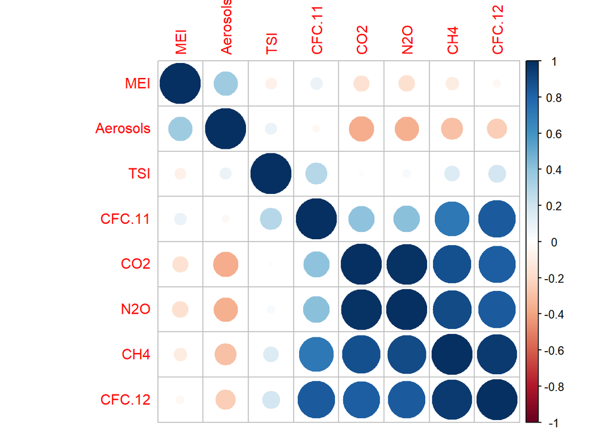

```r
library(corrplot)
corrplot(cor(TempData[,-c(1,2,11)]),method = "circle", order="hclust")
```

Yukaridaki korelasyon grafiginde Pozitif korelasyonlar mavi, negatif korelasyonlar kirmizi renkte gorulmektedir.Ornegin N2o ve CO2 arasindaki iliskinin korelasyonu yuksek cikmistir.Fakat CO2 ile MEI arasindaki iliskinin korelasyonu dusuktur.

Verimizi matrix haline donusturelim ;

```r
x <- model.matrix(lmod1)[,-11]
head(x,5)
```

```
##   (Intercept)   MEI    CO2     CH4     N2O  CFC.11  CFC.12 Aerosols      TSI
## 1           1 2.556 345.96 1638.59 303.677 191.324 350.113   0.0863 1366.102
## 2           1 2.167 345.52 1633.71 303.746 192.057 351.848   0.0794 1366.121
## 3           1 1.741 344.15 1633.22 303.795 192.818 353.725   0.0731 1366.285
## 4           1 1.130 342.25 1631.35 303.839 193.602 355.633   0.0673 1366.420
## 5           1 0.428 340.17 1648.40 303.901 194.392 357.465   0.0619 1366.234
```

Verimizden yanit degiskenini cikarip sadece aciklayici degiskenlerden olusan matrix formuna donusturduk.

x transpoz x in eigen valuelerini hesaplayalim;

```r
e <- eigen(t(x)%*%x)$values
e
```

```
## [1] 1.685102e+09 1.002420e+06 6.284630e+04 1.365592e+04 2.009339e+03
## [6] 2.519922e+02 1.303370e+02 1.937460e-01 2.289110e-05
```

#### KOSUL INDEKSI

Kapa degeri : sqrt(en buyuk ozdeger / en kucuk ozdeger)

```r
k <- sqrt(max(e)/min(e))
k
```

```
## [1] 8579852
```

Kapa degeri > 30 ise orta derece collinearity(ic iliski) , Kapa degeri > 100 ise guclu collinearity (ic iliski) oldugunu gosterir. Verimizde cikan sonucumuza gore guclu collinearity (ic iliski) problemi vardir. Bagimsiz degiskeni diger degiskenler cok fazla etkiliyor.

#### VIF

Vif degerlerine bakmak icin car paketi icinde olan hazir kod kullanilir.

```r
library(car)
vif(lmod1)
```

```
##       MEI       CO2       CH4       N2O    CFC.11    CFC.12  Aerosols       TSI
##  1.225696 27.996103 19.129508 61.037453 31.829321 93.498182  1.354470  1.140976
```

Vif degerinin 10 dan buyuk olmasi collinearity probleminin oldugunu soyler. CO2,CH4,N2O,CFC.11,CFC.12 degiskenlerimin degerleri 10 dan buyuk cikti collinearity(ic iliski) problemi vardir.

Hata ile ilgili varsayimlardan Otokorelasyon testlerini farkli bir veri uzerinden inceleyelim;

# 1- HATA ILE ILGILI VARSAYIMLAR

## C- OTOKORELASYON

Hatalar ile bir kaydirilmis hatalar arasindaki otokorelasyondur.Korelasyon iki tane degisken vektor arasinda bakilir. Zaman serilerinde ,mekansal verilerde ve panel(kesit) verilerinde bu durum incelenmistir. Onceden fitted y lere karsilik grafik cizdiriyorduk simdi modelimizdeki zaman degiskenine karsi cizdirecegiz.

# National Stock Exchange : Time Series

##### KAYNAK: https://www.kaggle.com/atulanandjha/national-stock-exchange-time-series

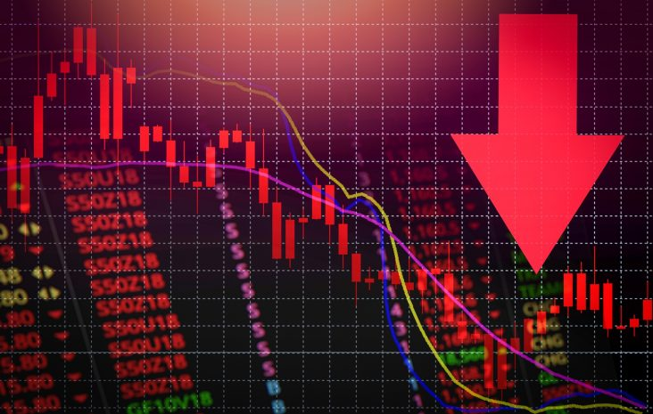

```r
NSTS=read.csv("C:/Users/CASPER/Desktop/infy_stock.csv", header=T)
head(NSTS,10)
```

```
##          Date Symbol Series Prev.Close    Open    High     Low    Last   Close
## 1  2015-01-01   INFY     EQ    1972.55 1968.95 1982.00 1956.90 1971.00 1974.40
## 2  2015-01-02   INFY     EQ    1974.40 1972.00 2019.05 1972.00 2017.95 2013.20
## 3  2015-01-05   INFY     EQ    2013.20 2009.90 2030.00 1977.50 1996.00 1995.90
## 4  2015-01-06   INFY     EQ    1995.90 1980.00 1985.00 1934.10 1965.10 1954.20
## 5  2015-01-07   INFY     EQ    1954.20 1965.00 1974.75 1950.00 1966.05 1963.55
## 6  2015-01-08   INFY     EQ    1963.55 1985.60 1997.00 1950.00 1979.25 1973.45
## 7  2015-01-09   INFY     EQ    1973.45 1980.10 2109.00 1913.05 2075.30 2074.45
## 8  2015-01-12   INFY     EQ    2074.45 2092.00 2119.20 2075.00 2112.95 2115.95
## 9  2015-01-13   INFY     EQ    2115.95 2107.80 2107.80 2075.00 2092.00 2088.90
## 10 2015-01-14   INFY     EQ    2088.90 2098.50 2133.00 2092.60 2129.00 2128.65
##       VWAP   Volume     Turnover Trades Deliverable.Volume X.Deliverble
## 1  1971.34   500691 9.870306e+13  14908             258080       0.5154
## 2  2003.25  1694580 3.394669e+14  54166            1249104       0.7371
## 3  2004.59  2484256 4.979911e+14  82694            1830962       0.7370
## 4  1954.82  2416829 4.724458e+14 108209            1772070       0.7332
## 5  1962.59  1812479 3.557162e+14  62463            1317720       0.7270
## 6  1972.78  3391230 6.690160e+14  92752            2686012       0.7920
## 7  2037.69 11215832 2.285439e+15 359214            3369489       0.3004
## 8  2099.40  3189722 6.696516e+14 107209            1818800       0.5702
## 9  2089.42  2200309 4.597374e+14  66676            1385009       0.6295
## 10 2110.88  2480315 5.235638e+14  53263            1832958       0.7390
```

### Veri Seti Aciklamasi ;

Ulusal Borsa: Zaman Serisi.Zaman serisi analizi icin Hint bilisim sirketlerinin ulusal borsa veri setidir. Hindistan Ulusal Borsasi (NSE) Mumbai, Maharashtra, Hindistan’da bulunan bir Hint borsasidir. Ulusal Menkul Kiymetler Borsasi (NSE) 1992 yilinda yetkisiz bir elektronik borsa olarak kuruldu. Hindistan Hukumeti’nin talebi uzerine onde gelen finans kuruluslari tarafindan tesvik edildi. Hindistan’in ciro ile yaptigi en buyuk borsa. 1994 yilinda elektronik ekran tabanli ticareti baslatti. Daha sonra, 2000 yilinda ulkede turunun ilk ornegi olan endeks futures ve internet ticareti baslatti. 248 gozlem 15 sutun bulunmakta.

### Degiskenler:

Date: Verilerin kaydedildigi tarih.

Symbol: Stokun NSE (Hindistan Ulusal Borsasi ) sembolu.

Series: Bu hisse senedinin serisi. (EQ,BE,BL,BT,GC,IL)

Prev Close: Son gun kapanis noktasi.

Open: Mevcut gun acilis noktasi.

High: Mevcut gunun en yuksek noktasi.

Low: Mevcut gunun en dusuk noktasi.

Last: Son islem gununde belirli bir hisse senedi veya borsa endeksi icin son teklif edilen islem fiyati.

Close: Gecerli gun icin kapanis noktasi.

VWAP: Hacim agirlikli ortalama fiyat anlamina gelir, bir varligin belirli bir zaman araligi icin hacme gore agirligi alinmis ortalama fiyatidir.

Volume: Belirli bir zaman diliminde islem goren menkul kiymet tutari. Her alici icin bir satici var ve her islem toplam hacim sayisina katkida bulunuyor.

Turnover: Hisse senedinin o gune kadar toplam cirosu.

Trades: Hisse senedi alim veya satim sayisi.

Deliverable: Bir grup insandan (bugunden once demat hesabida bu hisseleri olan ve bugun satis yapan) baska bir grup insana (bu hisseleri satin almis olan ve bu hisseleri T+2 gunlerine kadar alacak olan) hareket eden hisse miktari. Demat hesabi(Hindistan Internet Borsasi)).

%Deliverble: Bu hisse senedinin teslimat yuzdesi.

VWAP’yi ozellikle guclu bir gosterge haline getiren ortalama fiyat hesaplamasinda hacmi kullanma seklidir. VWAP, hacmin gucuyle fiyat hareketini birlestirerek pratik ve kullanimi kolay bir gosterge yaratir. Alim satim yapanlar VWAP’yi bir trend onaylama ya da giris ve cikis noktalarini belirleme araci olarak kullanabilir. VWAP her gunun basinda sifirlanir. Alim satim yapmak istedigimizde, VWAP’in altinda almak ve ustunde satmak karlidir. Fiyatin bugunku degerinin ustunde mi alim yaptik yoksa altinda mi alim yaptik bunu belirlememizi saglar. Fiyat VWAP uzerinde ise, satmak icin iyi bir gun ici fiyattir. Fiyat VWAP’in altindaysa, satin almak icin iyi bir gun ici fiyatidir.

##### Degiskenleri Aciklamada Kullanilan Ek Bilgi Kaynaklari:

https://www.investopedia.com/articles/trading/11/trading-with-vwap-mvwap.asp https://www.binance.vision/tr/economics/volume-weighted-average-price-vwap-explained

Regresyon modelimizi kuralim;

VWAP, hacmin gucuyle fiyat hareketini birlestirerek pratik ve kullanimi kolay bir gosterge yaratir. Bagimli degiskenimiz VWAP tir.(Yanit degiskeni) Aciklayici degisken olarak da Volume,High,Low,Close,Last kullanarak regresyon modeli kuralim, zaman serisi icin year degiskenini modele dahil etmiyoruz ;

```r
model<-lm(VWAP~Volume+
            High+
           Low+
            Close+
            Last,data=NSTS)
```

```r
summary(model)
```

```
##
## Call:
## lm(formula = VWAP ~ Volume + High + Low + Close + Last, data = NSTS)
##
## Residuals:
##      Min       1Q   Median       3Q      Max
## -16.7176  -1.8093  -0.0132   1.9931  23.8569
##
## Coefficients:
##               Estimate Std. Error t value Pr(>|t|)
## (Intercept)  1.983e+00  1.282e+00   1.547   0.1232
## Volume      -1.505e-07  1.993e-07  -0.755   0.4509
## High         3.824e-01  2.165e-02  17.666  < 2e-16 ***
## Low          2.517e-01  2.317e-02  10.861  < 2e-16 ***
## Close        5.419e-01  8.214e-02   6.597 2.62e-10 ***
## Last        -1.785e-01  8.325e-02  -2.144   0.0331 *
## ---
## Signif. codes:  0 '***' 0.001 '**' 0.01 '*' 0.05 '.' 0.1 ' ' 1
##
## Residual standard error: 4.374 on 242 degrees of freedom
## Multiple R-squared:  0.9999, Adjusted R-squared:  0.9999
## F-statistic: 7.22e+05 on 5 and 242 DF,  p-value: < 2.2e-16
```

Regresyon modelimiz icin p-value degerimiz yaklasik olarak 0 dir ,0.05 den kucuk oldugu icin H0 hipotezimiz reddedilir yani kurulan regresyon modeli anlamlidir. Kurdugum regresyon modelinde VWAP i en cok etkileyen degiskenleri kullandigim icin Adjusted R-squared degerim 0.9999 , yani 1 e cok yakin bir deger cikmistir.

Otokorelasyon hatalar ile bir kaydirilmis hatalar arasindaki otokorelasyondur.Korelasyon iki degisken arasindaki iliskiyi gosterir. Korelasyon anlamliligi testine t istatistigi ile bakilir.

Bir gecikmeliler ile hatalarin sacinim grafigini cizdirelim;

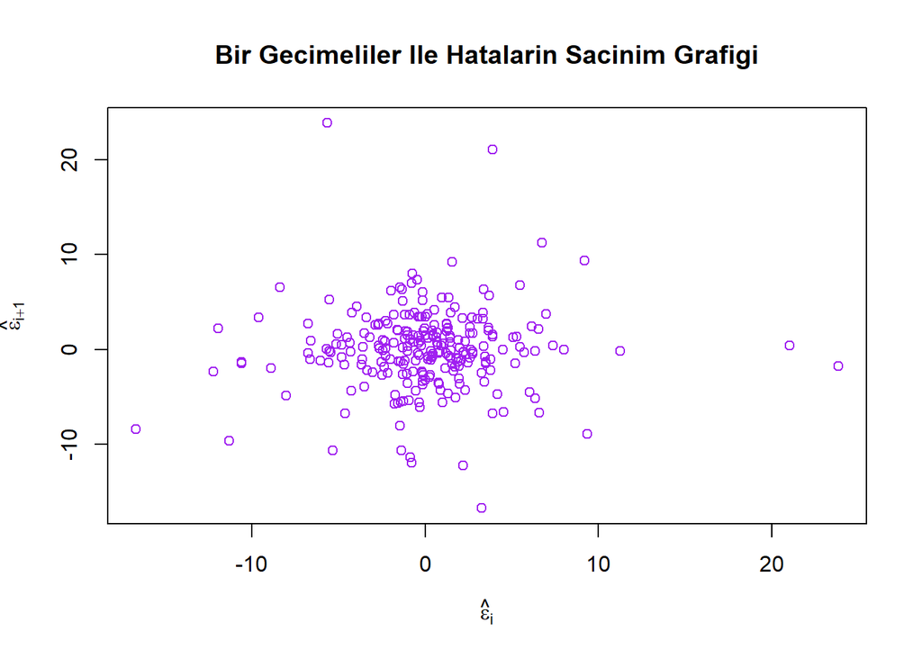

```r
n<-length(residuals(model))
plot(tail(residuals(model),n-1),
     head(residuals(model),n-1),
     xlab = expression(hat(epsilon)[i]),
     ylab=expression(hat(epsilon)[i+1]),main="Bir Gecimeliler Ile Hatalarin Sacinim Grafigi",col="purple")
```

Gecikmeli artiklar icin kuyruk kismindan ve bas kismindan birer tane atip ikisi arasinda sacinim grafigi cizdirdik. Hicbir model bilmiyorken iliskiyi anlamak icin birini yanit degiskeni birini aciklayici degisken yapip regresyon modeli kurulur. Eger model anlamli cikarsa aralarindaki iliski anlamlidir denir.Korelasyon testi ile daha net sonuc gorebiliriz.

```r
cor.test(tail(residuals(model),n-1),
         head(residuals(model),n-1))
```

```
##
##  Pearson's product-moment correlation
##
## data:  tail(residuals(model), n - 1) and head(residuals(model), n - 1)
## t = 0.73268, df = 245, p-value = 0.4645
## alternative hypothesis: true correlation is not equal to 0
## 95 percent confidence interval:
##  -0.07851958  0.17058208
## sample estimates:
##        cor
## 0.04675817
```

Korelasyon testi sonucumuza gore p-value=0.4645 ,0.05 den buyuk oldugu icin hatalar ile bir gecikmeliler arasinda iliski yoktur.

#### DURBIN -WATSON TEST ISTATISTIGI

H0 : Otokorelasyon yoktur. H1 : Otokorelasyon vardir.

H0 RED ise otokorelasyon vardir. H0 KABUL ise otokorelasyon yoktur. Modelin anlamliligina bakariz.

```r
library(lmtest)
dwtest(VWAP~Volume+
            High+
           Low+
            Close+
            Last,data=NSTS)
```

```
##
##  Durbin-Watson test
##
## data:  VWAP ~ Volume + High + Low + Close + Last
## DW = 1.906, p-value = 0.2024
## alternative hypothesis: true autocorrelation is greater than 0
```

Durbin Watson testimizin sonucuna gore p-value=0.2024,0.05 den buyuk oldugundan H0 hipotezi kabul edilir yani otokorelasyon yoktur.

Durbin-watson testi gecikmelere sadece birinci dereceden bakiyor bu yuzden daha yuksek derecelerden gecikmelere bakmak icin Breusch Godfrey testi yapilir.

#### BREUSCH-GOLDFREY TEST ISTATISTIGI

H0 : Otokorelasyon yoktur. H1 : Otokorelasyon vardir.

H0 KABUL Otokorelasyon yok. H0 RED Otokorelasyon var. Modelin anlamliligina degil gecikmelilerin kastsayilarinin modele kattigi anlamlara bakariz.

```r
library(lmtest)
bgtest(VWAP~Volume+
            High+
           Low+
            Close+
            Last,data=NSTS)
```

```
##
##  Breusch-Godfrey test for serial correlation of order up to 1
##
## data:  VWAP ~ Volume + High + Low + Close + Last
## LM test = 0.55689, df = 1, p-value = 0.4555
```

Breusch Goldfrey testimizin sonucuna gore p-value=0.4555 ,0.05 den buyuk oldugundan h0 hipotezi kabul edilir yani otokorelasyon yoktur.